# 12 Analyze your data

After completing this set of activities, you should be able to:

- assess what information is contained in a data set.
- decide what type of descriptive statistics to apply according to whether a variable is continuous or categorical.
- distinguish between a null and alternative hypothesis and interpret the results of a statistical test for significant differences among means and frequencies.

Before we get started we will need to load our `R` libraries that contain the functions we will need to analyze our data.

```r
# load libraries for reporting
library(knitr)

# load libraries for data import
library(readr)
library(here)
library(janitor)

# load libraries for data wrangling
library(dplyr)
library(tidyr)
library(broom)

# load libraries for plotting
library(ggplot2)

# load library for inferential stats
library(infer)
library(chisq.posthoc.test)
```

## 12.1 Germination Data

### 12.1.1 Get the data

Go to the `GoogleSheet` that contains the germination counts for your lab and select the tab for your group.

- Double check that the data has been entered correctly.
- Go to `File` -> `Download` -> `Comma Separated Values (.csv)` to download your data as a comma-delimited file.
- Use your `File Explorer` if you are on a Windows computer and `Finder` of you are on a Mac and navigate to the `Downloads` folder. You should see the file you just downloaded there.

Now we have to upload the file to our posit cloud `R project`.

- In the `File` tab (lower right panel) navigate to the `data` folder.
- Select the `Uploads` button.
- Use the dialog box to select `Choose File` button and navigate to your file in the downloads folder.
- Select your file and upload it.
- Check the box next to the file you just uploaded it and use the `Rename` button to rename it to `germination.csv`.

Now we are ready to read in our germination data as a `data.frame` object that we can compute on in `R`. We will create three objects, the first is a generated data set comparing the impacts of different deicers on mung beans, the second the data radish seed data sets from Section A and B.

```r
# read in example data set
germination_ex <- read_delim(here("data", "germination-1.csv"), delim = ",") %>%
  clean_names() %>%
  unite(treatment, deicer, treatment_level,
        sep = "_", remove = FALSE) %>%
  mutate(treatment_level = factor(treatment_level,
                                   levels = c("high", "medium", "low", "trace")))

# read in Section A data set
germination_A <- read_delim(here("data", "germination_Section-A.csv"), delim = ",") %>%
  clean_names() %>%
  unite(treatment, deicer, treatment_level,
        sep = "_", remove = FALSE) %>%
  mutate(treatment_level = factor(treatment_level,
                                   levels = c("high", "medium", "low", "trace")))

# read in Section B data set
germination_B <- read_delim(here("data", "germination_Section-B.csv"), delim = ",") %>%
  clean_names() %>%
  unite(treatment, deicer, treatment_level,
        sep = "_", remove = FALSE) %>%
  mutate(treatment_level = factor(treatment_level,
                                   levels = c("high", "medium", "low", "trace")))

# take a look at first few lines
head(germination_ex) %>%
  kable()
```

| treatment | deicer | treatment_level | concentration | units | replicate | seed_number | germination | setup_date | observation_date | observation_time | initials | notes |
| --- | --- | --- | --- | --- | --- | --- | --- | --- | --- | --- | --- | --- |
| rock_salt_high | rock_salt | high | 10 | mg/L | 1 | 1 | no_germination | 2025-03-01 | 2025-03-02 | 08:00:00 | JD | No issues |
| rock_salt_high | rock_salt | high | 10 | mg/L | 1 | 2 | germinated | 2025-03-01 | 2025-03-02 | 08:00:00 | JD | No issues |
| rock_salt_high | rock_salt | high | 10 | mg/L | 1 | 3 | no_germination | 2025-03-01 | 2025-03-02 | 08:00:00 | JD | No issues |
| rock_salt_high | rock_salt | high | 10 | mg/L | 1 | 4 | germinated | 2025-03-01 | 2025-03-02 | 08:00:00 | JD | No issues |
| rock_salt_high | rock_salt | high | 10 | mg/L | 1 | 5 | no_germination | 2025-03-01 | 2025-03-02 | 08:00:00 | JD | No issues |
| rock_salt_high | rock_salt | high | 10 | mg/L | 1 | 6 | no_germination | 2025-03-01 | 2025-03-02 | 08:00:00 | JD | No issues |

**Consider this**

Take a look at the `data.frame` object holding your data by clicking on it in the `Environment` pane (bottom left) or using `View(object_name)`.

Describe how your data is organized:

- what information is in each row?
- what information is in each column?

Find your explanatory (independent) and response (dependent) variables in the data set.

Assess what type of data you have in each column:

- is it continuous or categorical?
- what groups are you interested in comparing?

Finally, determine which summary/descriptive statistics are appropriate to summarize this data set and how you would visualize your data.

**Answer**

Each row represents one seed. And each column contains information for one variable.

Your explanatory variables are the individual treatments, this is categorical data. Similarly, your response variable is the germination data which is categorical with two possible values “germinated” and “not germinated”.

We want to know the total number of seeds that germinated and did not germinate across all replicates for each treatment, and what proportion of the total number of seeds germinated.

Because we have categorical data and want to visualize how the data is distributed across our categories, we will want to use a bar plot to visualize our data.

We’ve discussed the need to QA/QC data. Usually whenever we read in data sets it can be helpful to create a few overview tables that allow us to look at the different parameters that were recorded (should be organized in columns) and number of observations in various groupings. These tables can be useful for describing your experimental design as well as an overview of what your data set looked like for your results section.

Let’s start with our example data set:

```r
# count number of observations per deicer
germination_ex %>%
  group_by(deicer) %>%
  count() %>%
  kable()
```

| deicer | n |
| --- | --- |
| cheese_brine | 180 |
| comm_blend | 180 |
| control | 60 |
| rock_salt | 180 |

**Give it a try**

Create a copy of the code and then modify it to produce a similar table that shows the number of observation per treatment and replicate.

Then produce a version of each of the two tables for the other two data sets.

**Answer**

You can choose any set of columns to group by (remember to not use quotation marks and separate them by a comma) as long as you type the column name in exactly:

```r
# count number of observations per treatment and replicate
germination_ex %>%
  group_by(treatment, replicate) %>%
  count() %>%
  kable()
```

| treatment | replicate | n |
| --- | --- | --- |
| cheese_brine_high | 1 | 20 |
| cheese_brine_high | 2 | 20 |
| cheese_brine_high | 3 | 20 |
| cheese_brine_low | 1 | 20 |
| cheese_brine_low | 2 | 20 |
| cheese_brine_low | 3 | 20 |
| cheese_brine_medium | 1 | 20 |
| cheese_brine_medium | 2 | 20 |
| cheese_brine_medium | 3 | 20 |
| comm_blend_high | 1 | 20 |
| comm_blend_high | 2 | 20 |
| comm_blend_high | 3 | 20 |
| comm_blend_low | 1 | 20 |
| comm_blend_low | 2 | 20 |
| comm_blend_low | 3 | 20 |
| comm_blend_medium | 1 | 20 |
| comm_blend_medium | 2 | 20 |
| comm_blend_medium | 3 | 20 |
| control_high | 1 | 20 |
| control_high | 2 | 20 |
| control_high | 3 | 20 |
| rock_salt_high | 1 | 20 |
| rock_salt_high | 2 | 20 |
| rock_salt_high | 3 | 20 |
| rock_salt_low | 1 | 20 |
| rock_salt_low | 2 | 20 |
| rock_salt_low | 3 | 20 |
| rock_salt_medium | 1 | 20 |
| rock_salt_medium | 2 | 20 |
| rock_salt_medium | 3 | 20 |

Then for the other tables you just have to change the object name in the first line.

```r
# count number of observations per deicer
germination_A %>%
  group_by(deicer) %>%
  count() %>%
  kable()
```

| deicer | n |
| --- | --- |
| Fusion2330 | 200 |
| NaCl | 240 |
| control | 60 |

```r
# count number of observations per treatment and replicate
germination_A %>%
  group_by(treatment, replicate) %>%
  count() %>%
  kable()
```

| treatment | replicate | n |
| --- | --- | --- |
| Fusion2330_high | 1 | 20 |
| Fusion2330_high | 2 | 20 |
| Fusion2330_high | 3 | 20 |
| Fusion2330_low | 1 | 20 |
| Fusion2330_medium | 1 | 20 |
| Fusion2330_medium | 2 | 20 |
| Fusion2330_medium | 3 | 20 |
| Fusion2330_trace | 1 | 20 |
| Fusion2330_trace | 2 | 20 |
| Fusion2330_trace | 3 | 20 |
| NaCl_high | 1 | 20 |
| NaCl_high | 2 | 20 |
| NaCl_high | 3 | 20 |
| NaCl_low | 1 | 20 |
| NaCl_low | 2 | 20 |
| NaCl_low | 3 | 20 |
| NaCl_medium | 1 | 20 |
| NaCl_medium | 2 | 20 |
| NaCl_medium | 3 | 20 |
| NaCl_trace | 1 | 20 |
| NaCl_trace | 2 | 20 |
| NaCl_trace | 3 | 20 |
| control_NA | 1 | 20 |
| control_NA | 2 | 20 |
| control_NA | 3 | 20 |

```r
# count number of observations per treatment overall
germination_A %>%
  group_by(treatment) %>%
  count() %>%
  kable()
```

| treatment | n |
| --- | --- |
| Fusion2330_high | 60 |
| Fusion2330_low | 20 |
| Fusion2330_medium | 60 |
| Fusion2330_trace | 60 |
| NaCl_high | 60 |
| NaCl_low | 60 |
| NaCl_medium | 60 |
| NaCl_trace | 60 |
| control_NA | 60 |

```r
# count number of observations per deicer
germination_B %>%
  group_by(deicer) %>%
  count() %>%
  kable()
```

| deicer | n |
| --- | --- |
| CaCl | 99 |
| DI-water | 60 |
| MgCl | 101 |
| NaCl | 60 |
| beet | 120 |
| tap-water | 60 |
| urea | 120 |

```r
# count number of observations per treatment and replicate
germination_B %>%
  group_by(treatment, replicate) %>%
  count() %>%
  kable()
```

| treatment | replicate | n |
| --- | --- | --- |
| CaCl_high | 1 | 19 |
| CaCl_high | 3 | 20 |
| CaCl_low | 1 | 20 |
| CaCl_low | 2 | 20 |
| CaCl_low | 3 | 20 |
| DI-water_NA | 1 | 20 |
| DI-water_NA | 2 | 20 |
| DI-water_NA | 3 | 20 |
| MgCl_high | 1 | 22 |
| MgCl_high | 2 | 20 |
| MgCl_low | 1 | 21 |
| MgCl_low | 2 | 18 |
| MgCl_low | 3 | 20 |
| NaCl_high | 1 | 20 |
| NaCl_high | 2 | 20 |
| NaCl_high | 3 | 20 |
| beet_high | 1 | 20 |
| beet_high | 2 | 20 |
| beet_high | 3 | 20 |
| beet_low | 1 | 20 |
| beet_low | 2 | 20 |
| beet_low | 3 | 20 |
| tap-water_NA | 1 | 20 |
| tap-water_NA | 2 | 20 |
| tap-water_NA | 3 | 20 |
| urea_high | 1 | 20 |
| urea_high | 2 | 20 |
| urea_high | 3 | 20 |
| urea_low | 1 | 20 |
| urea_low | 2 | 20 |
| urea_low | 3 | 20 |

```r
# count number of observations per treatment overall
germination_B %>%
  group_by(treatment) %>%
  count() %>%
  kable()
```

| treatment | n |
| --- | --- |
| CaCl_high | 39 |
| CaCl_low | 60 |
| DI-water_NA | 60 |
| MgCl_high | 42 |
| MgCl_low | 59 |
| NaCl_high | 60 |
| beet_high | 60 |
| beet_low | 60 |
| tap-water_NA | 60 |
| urea_high | 60 |
| urea_low | 60 |

We can see from these overview tables that we have a few plates where we didn’t get exactly 20 seeds in the petri dish. We also seem to have some treatments where a replicate or two is missing.

### 12.1.2 Summarize your results

Now, we can actually start analyzing our results. First, we will want to identify ways to summarize our data so we can identify broad trends and compare the different treatments.

**Consider this**

Your `data.frame` contains the raw data.

Suggest 2-3 ways that you can summarize your data in a meaningful way to describe your results in the context of the hypothesis you are exploring with this experiment. Explain why you think these would be appropriate data analysis methods.

**Answer**

We are going to calculate the total number and relative proportion of seeds that germinated for each treatment.

A good visualization would be a bar plot where the height of each bar on the y-axis indicate the proportion of seeds that germinated.

```r
# tidy data set
germination_ex %>%
  group_by(deicer, treatment_level) %>% # group data by treatment
  count(germination) %>%                # count number seeds germinated
  mutate(percent = n/sum(n)*100) %>%
  filter(germination == "germinated") %>%
  kable(digits = 2)
```

| deicer | treatment_level | germination | n | percent |
| --- | --- | --- | --- | --- |
| cheese_brine | high | germinated | 39 | 65.00 |
| cheese_brine | medium | germinated | 53 | 88.33 |
| cheese_brine | low | germinated | 52 | 86.67 |
| comm_blend | high | germinated | 24 | 40.00 |
| comm_blend | medium | germinated | 36 | 60.00 |
| comm_blend | low | germinated | 50 | 83.33 |
| control | high | germinated | 55 | 91.67 |
| rock_salt | high | germinated | 11 | 18.33 |
| rock_salt | medium | germinated | 28 | 46.67 |
| rock_salt | low | germinated | 33 | 55.00 |

Table 12.1: Summary of germination success after 48 hrs. Total number (n) and percent of seeds that germinated.

This table gives you two summary statistics, but the table might not be the best way to present your data for easy comparison in a report.

An easier way to compare would be to pivot our data set into a wider format:

```r
# wide table
germination_ex %>%
  group_by(deicer, treatment_level) %>% # group data by treatment
  count(germination) %>%                # count number seeds germinated
  mutate(percent = n/sum(n)*100) %>%
  select(-n) %>%
  filter(germination == "germinated") %>%
  pivot_wider(names_from = treatment_level, values_from = percent) %>%
  kable(digits = 2)
```

| deicer | germination | high | medium | low |
| --- | --- | --- | --- | --- |
| cheese_brine | germinated | 65.00 | 88.33 | 86.67 |
| comm_blend | germinated | 40.00 | 60.00 | 83.33 |
| control | germinated | 91.67 | NA | NA |
| rock_salt | germinated | 18.33 | 46.67 | 55.00 |

Table 12.2: Summary of germination success after 48 hrs for each deicer and concentration. Total number (n) and percent of seeds that germinated.

**Give it a try**

Modify the code to create similar tables for your data sets.

**Answer**

```r
# wide table
germination_A %>%
  group_by(deicer, treatment_level) %>% # group data by treatment
  count(germination) %>%                # count number seeds germinated
  mutate(percent = n/sum(n)*100) %>%
  select(-n) %>%
  filter(germination == "germinated") %>%
  pivot_wider(names_from = treatment_level, values_from = percent) %>%
  kable(digits = 2)
```

| deicer | germination | high | medium | low | trace | NA |
| --- | --- | --- | --- | --- | --- | --- |
| Fusion2330 | germinated | 98.33 | 95.00 | 100 | 88.33 | NA |
| NaCl | germinated | 65.00 | 96.67 | 100 | 98.33 | NA |
| control | germinated | NA | NA | NA | NA | 98.33 |

```r
# wide table
germination_B %>%
  group_by(deicer, treatment_level) %>% # group data by treatment
  count(germination) %>%                # count number seeds germinated
  mutate(percent = n/sum(n)*100) %>%
  select(-n) %>%
  filter(germination == "germinated") %>%
  pivot_wider(names_from = treatment_level, values_from = percent) %>%
  kable(digits = 2)
```

| deicer | germination | high | low | NA |
| --- | --- | --- | --- | --- |
| CaCl | germinated | 82.05 | 73.33 | NA |
| DI-water | germinated | NA | NA | 100.00 |
| MgCl | germinated | 95.24 | 98.31 | NA |
| NaCl | germinated | 65.00 | NA | NA |
| beet | germinated | 100.00 | 100.00 | NA |
| tap-water | germinated | NA | NA | 98.33 |
| urea | germinated | 100.00 | 100.00 | NA |

Data visualizations are frequently more helpful present your results compared to tables with numbers, so let’s create a grouped bar chart visualizing the proportion of seeds that did/did not germinate.

We’ll start by comparing the proportion that germinated for each treatment.

[figure not shown]

Figure 12.1: Comparison of germination success of mung beans exposed to different deicers and concentration levels (high = 10mg/L, medium = 1 mg/L, low = 0.1 mgl/L).

```r
# create table with % germinated
summary <- germination_ex |>
  group_by(deicer, treatment_level) |> # group data by treatment
  count(germination) |>                # count number seeds germinated
  mutate(percent = n/sum(n)*100)       # calculate proportion

# subset data to show % not germinated ----
germination <- summary |>
  filter(germination == "germinated")

# create bar plot with frequency
ggplot(germination, aes(x = deicer,                  # specify categories on x axis
                        y = percent,
                        fill = treatment_level)) +   # specify how to group data
  geom_bar(stat = "identity",                        # length of bar indicates number of observations
           width = .75,                              # space between groups
           position = position_dodge(.8,
                                     preserve = "single"), # space between bars in group
           color = "black") +                        # line color of bar
  scale_fill_manual(values = c("#4E5283",
                               "#7871AA",
                               "#D9BBF9",
                               "#AA9FB1")) +      # modify for custom colors
  labs(x = "deicer type",                    # x-axis title
       y = "% of seeds that did not germinate") +                  # y-axis title
  theme_classic() +                                  # specify theme
  theme(legend.position = "bottom")                  # legend position
```

**Give it a try**

Modify the code to create a similar visualization for your data sets.

**Answer**

[figure not shown]

```r
# create table with % germinated
summary <- germination_A |>
  group_by(deicer, treatment_level) |> # group data by treatment
  count(germination) |>                # count number seeds germinated
  mutate(percent = n/sum(n)*100)       # calculate proportion

# subset data to show % not germinated ----
no_germination <- summary |>
  filter(germination == "germinated")

# create bar plot with frequency
ggplot(no_germination, aes(x = deicer,                  # specify categories on x axis
                        y = percent,
                        fill = treatment_level)) +   # specify how to group data
  geom_bar(stat = "identity",                        # length of bar indicates number of observations
           width = .75,                              # space between groups
           position = position_dodge(.8,
                                     preserve = "single"), # space between bars in group
           color = "black") +                        # line color of bar
  scale_fill_manual(values = c("#4E5283",
                               "#7871AA",
                               "#D9BBF9",
                               "#ECE0F8",
                               "#AA9FB1")) +      # modify for custom colors
  labs(x = "deicer type",                    # x-axis title
       y = "% of seeds that did not germinate",  # y-axis title
       title = "Data set section A") +
  theme_classic() +                                  # specify theme
  theme(legend.position = "bottom")                  # legend position
```

[figure not shown]

```r
# create table with % germinated
summary <- germination_B |>
  group_by(deicer, treatment_level) |> # group data by treatment
  count(germination) |>                # count number seeds germinated
  mutate(percent = n/sum(n)*100)       # calculate proportion

# subset data to show % not germinated ----
no_germination <- summary |>
  filter(germination == "germinated")

# create bar plot with frequency
ggplot(no_germination, aes(x = deicer,                  # specify categories on x axis
                        y = percent,
                        fill = treatment_level)) +   # specify how to group data
  geom_bar(stat = "identity",                        # length of bar indicates number of observations
           width = .75,                              # space between groups
           position = position_dodge(.8,
                                     preserve = "single"), # space between bars in group
           color = "black") +                        # line color of bar
  scale_fill_manual(values = c("#4E5283",
                               "#7871AA",
                               "#D9BBF9",
                               "#ECE0F8",
                               "#AA9FB1")) +      # modify for custom colors
  labs(x = "deicer type",                    # x-axis title
       y = "% of seeds that did not germinate",  # y-axis title
       title = "Data set section B") +
  theme_classic() +                                  # specify theme
  theme(legend.position = "bottom")                  # legend position
```

A lot of times it can be helpful to generate several exploratory plots that allow us to think through the data set. So let’s create a similar visualization that shows the proportion for each treatment that *did not germinate* as this might let us see certain patterns more clearly.

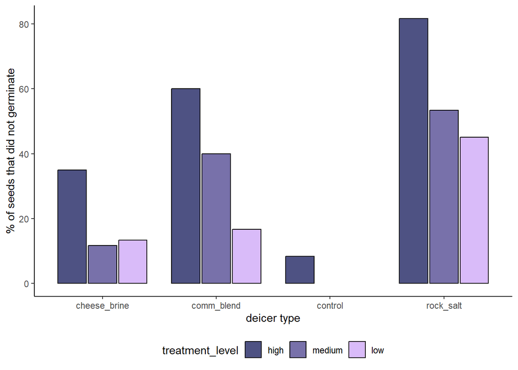

Figure 12.2: Comparison of germination inhibition of mung beans for different deicers and concentration levels (high = 10mg/L, medium = 1 mg/L, low = 0.1 mgl/L).

```r
# create table with % germinated
summary <- germination_ex |>
  group_by(deicer, treatment_level) |> # group data by treatment
  count(germination) |>                # count number seeds germinated
  mutate(percent = n/sum(n)*100)       # calculate proportion

# subset data to show % not germinated ----
no_germination <- summary |>
  filter(germination == "no_germination")

# create bar plot with frequency
ggplot(no_germination, aes(x = deicer,                  # specify categories on x axis
                        y = percent,
                        fill = treatment_level)) +   # specify how to group data
  geom_bar(stat = "identity",                        # length of bar indicates number of observations
           width = .75,                              # space between groups
           position = position_dodge(.8,
                                     preserve = "single"), # space between bars in group
           color = "black") +                        # line color of bar
  scale_fill_manual(values = c("#4E5283",
                               "#7871AA",
                               "#D9BBF9",
                               "#ECE0F8",
                               "#AA9FB1")) +      # modify for custom colors
  labs(x = "deicer type",                    # x-axis title
       y = "% of seeds that did not germinate") +                  # y-axis title
  theme_classic() +                                  # specify theme
  theme(legend.position = "bottom")                  # legend position
```

**Give it a try**

Modify the code to create a similar visualization for your data sets.

**Answer**

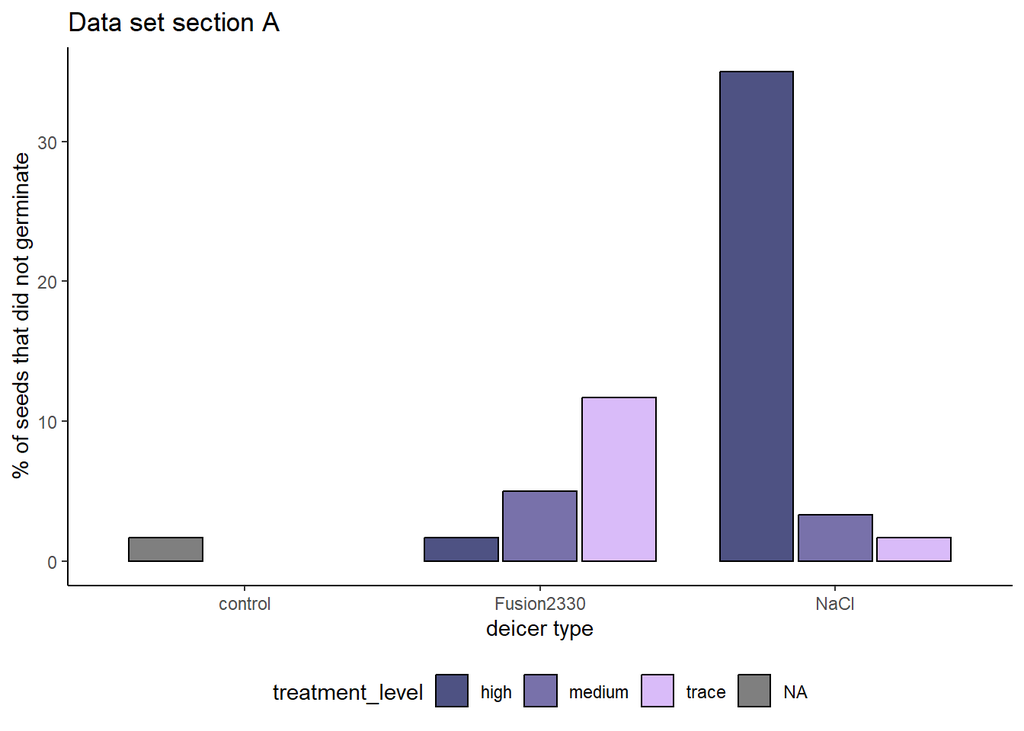

```r
# create table with % germinated
summary <- germination_A |>
  group_by(deicer, treatment_level) |> # group data by treatment
  count(germination) |>                # count number seeds germinated
  mutate(percent = n/sum(n)*100)       # calculate proportion

# subset data to show % not germinated ----
no_germination <- summary |>
  filter(germination == "no_germination")

# create bar plot with frequency
ggplot(no_germination, aes(x = deicer,                  # specify categories on x axis
                        y = percent,
                        fill = treatment_level)) +   # specify how to group data
  geom_bar(stat = "identity",                        # length of bar indicates number of observations
           width = .75,                              # space between groups
           position = position_dodge(.8,
                                     preserve = "single"), # space between bars in group
           color = "black") +                        # line color of bar
  scale_fill_manual(values = c("#4E5283",
                               "#7871AA",
                               "#D9BBF9",
                               "#ECE0F8",
                               "#AA9FB1")) +      # modify for custom colors
  labs(x = "deicer type",                    # x-axis title
       y = "% of seeds that did not germinate",  # y-axis title
       title = "Data set section A") +
  theme_classic() +                                  # specify theme
  theme(legend.position = "bottom")                  # legend position
```

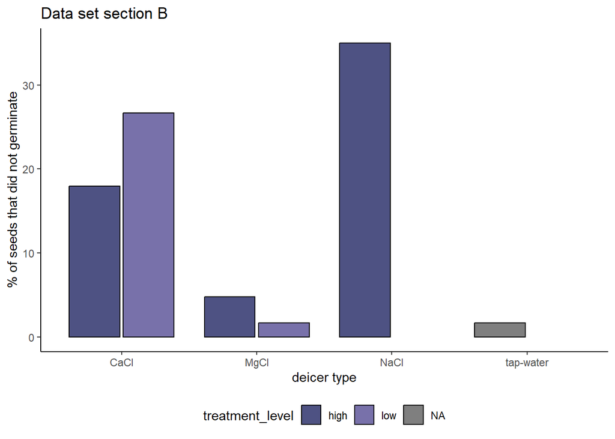

```r
# create table with % germinated
summary <- germination_B |>
  group_by(deicer, treatment_level) |> # group data by treatment
  count(germination) |>                # count number seeds germinated
  mutate(percent = n/sum(n)*100)       # calculate proportion

# subset data to show % not germinated ----
no_germination <- summary |>
  filter(germination == "no_germination")

# create bar plot with frequency
ggplot(no_germination, aes(x = deicer,                  # specify categories on x axis
                        y = percent,
                        fill = treatment_level)) +   # specify how to group data
  geom_bar(stat = "identity",                        # length of bar indicates number of observations
           width = .75,                              # space between groups
           position = position_dodge(.8,
                                     preserve = "single"), # space between bars in group
           color = "black") +                        # line color of bar
 scale_fill_manual(values = c("#4E5283",
                               "#7871AA",
                               "#D9BBF9",
                               "#ECE0F8",
                               "#AA9FB1")) +      # modify for custom colors
  labs(x = "deicer type",                    # x-axis title
       y = "% of seeds that did not germinate",  # y-axis title
       title = "Data set section B") +
  theme_classic() +                                  # specify theme
  theme(legend.position = "bottom")                  # legend position
```

**Give it a try**

Usually for your report you would chose to either include a table or a visualization that summarizes your data. Here you would also need to decide whether the germination or inhibition version of your figure is more informative.

In either case you would include a descriptive figure or table title/caption that describes how to interpret the figure. As a rule of thumb, you should have enough information in the caption that the reader can understand the figure even without reading the methods/results.

Then you should describe your results referencing your figure/table, however, your reader should be able to have the full picture of your results even without seeing the actual figure/table. A good template to use is to start with the broad pattern and then highlight important details. A good description of results contextualizes them for the reader. For example, instead of just listing out values provide context and help your reader see the patterns by using terms like “higher” “lower”, “similar” or highlighting certain results as “notably, …”, “except for…”. You have already done all the thinking, guide your reader through what you’ve found.

Describe your results. Remember, at this point you should not be interpreting them. Consider this thinking out loud in a way where you have a set of notes that you can then edit for your report.

**Answer**

Your description could look something like this:

Broad pattern:

or

> Both rock salt and the commercial blend show a similar pattern of a dose-dependent relationship where germination success decreases with increasing concentrations.

Details

or

> However, this effect was strong for rock salt (18 - 55% germination success) compared to the commercial blend (40 - 83% germination success).

It’s important that we add this context of actual numbers because it is quite different if 100% germinated in the control and 78% in the experimental treatment or something more similar to what we observe here.

Here are some additional examples of what a description could look like:

**Emphasize on “Broad Pattern First, Then Details” formula:**

Overall, germination rates varied among deicer treatments, with rock salt having the strongest negative impact, the cheese brine having the least impact, and the commercial blend showing an intermediate effect. The control group had the highest germination rate (91.67%), indicating baseline germination without deicer exposure.

Among the treatments, rock salt at high concentration had the lowest germination (18.33%), with a dose-dependent increase at medium (46.67%) and low (55.00%) concentrations. The commercial blend also showed a negative effect, but not as severe as rock salt, with germination increasing from 40.00% at high concentration to 60.00% at medium and 83.33% at low.

In contrast, the cheese brine had relatively little impact on germination. Even at the highest concentration, 65.00% of seeds germinated, and the rates at medium (88.33%) and low (86.67%) were similar to the control.

**Emphasis on Highlighting Notable Findings**

Notably, the rock salt treatment had the lowest germination rates, with only 18.33% of seeds germinating at the highest concentration. This is a stark contrast to the control (91.67%) and even the lowest rock salt concentration (55.00%). The commercial blend also reduced germination, but the effect was not as strong, with 40.00% germination at the highest concentration and an increase to 83.33% at the lowest concentration.

Interestingly, the cheese brine had the least effect, with germination at its highest concentration (65.00%) still higher than the rock salt and commercial blend at the same level. Medium and low cheese brine concentrations (88.33% and 86.67%) were nearly identical to the control, suggesting minimal impact.

**Emphasis on Highlighting Patterns with Comparative Terms**

Germination rates were lowest for rock salt, with a strong dose-dependent effect: only 18.33% of seeds germinated at high concentration, but rates increased at medium (46.67%) and low (55.00%) levels. The commercial blend also reduced germination, but its effects were less severe than rock salt, with the highest concentration resulting in 40.00% germination and the lowest concentration nearly matching the control (83.33% vs. 91.67%).

In contrast, the cheese brine had the least impact on germination. Even at the highest concentration (65.00%), germination remained substantially higher than rock salt or the commercial blend at equivalent concentrations. Medium and low concentrations of cheese brine (88.33% and 86.67%) were very similar to the control, indicating a minimal negative effect.

Descriptive or summary statistics are the important first step to summarizing our findings. However, at this point we don’t know if our observed differences in germination success are just due to sampling error or if they actually represent reality. For example let’s say that 42 seeds germinate in one treatment and 43 in another - are those numbers actually different from each other or does it fall within the natural variability of germination?

### 12.1.3 Test for statistical significance

Another way of stating this is to say that we want to make sure that our results are not due to sampling error, i.e. that our sample represents the true popoulation (i.e. all radish seeds) as a whole.

**Consider this**

Discuss what common factors we need consider to avoid bias in your sample due to **sampling error**.

**Answer**

The main causes are:

- **small sample size**: You would want to make sure that you are snagging enough individuals from each species to ensure that you are capturing the full range of body sizes for each species. The larger you sample size, the more likely you not only have individuals representing that full range, you should also end up with proportionally the same number of individuals in each weight category in your sample as there are in the entire population.
- **non-random sampling**: You need to make sure that you are sampling in a non-random manner. If you think the tiny ones are cuter and start picking up those more frequently then you would end up with a biased sample. If you are lazy, and just check the areas near your station, you might end up biasing towards larger ones e.g. because that is a spot where more food is available. If you are trying to spot them from far off and then driving towards them instead of having e.g. a random sampling grid you might only be spotting the larger ones etc.
- **outliers** can cause sampling error especially if the sample size is small. This is generally not something you can avoid by your sampling strategy, generally you want to have a sample size that is large enough that you can identify outliers.

When we are making inferences based on our data set either by generalizing from the sample to the population as a whole or when testing a specific hypothesis based on the data we’ve collected, we need to make sure that our conclusion are erroneous due to sampling error. Therefore, once we’ve calculated our descriptive statistics we will generally ask the question “**What is the probability that our results are the results of sampling error and do not reflect reality?**” and then use statistical tests to quantify that probability. The probability of results being due to sampling error increase the smaller our sample size is, the more variability that is observed, and the smaller the difference between metrics[^a05_inferent-stats-3] being compared.

Hypothesis testing is a formal process to make inferences about a population based on sample data. It involves evaluating two competing hypotheses to determine if the results are due to sampling error alone or are representative of the population. The key steps are the same, regardless of the the specific test being applied.

1. Define your research question or goal.
2. Specify what measurements you plan to compare and collect the data.
3. State your your null and alternate hypothesis and predict the outcome assuming the null hypothesis is true.
4. Specify a significance threshold.
5. Generate sampling distributions and calculate your test statistic.
6. Get the p-value.
7. Interpret the results and draw conclusions.

We have already gone through step 1 and 2 when we designed our experiment.

#### 12.1.3.1 Step 3: State your your null and alternate hypothesis and predict the outcome assuming the null hypothesis is true.

If you go back to the hypothesis you formulated, you would have created an “if-then-because” statement. We’ve said that the “because” component is your research hypothesis. This is your reasoning of why you expect to see a certain outcome.

The “if-then” component specifies what you would expect to observe in your data set. Now we need to restate this as a statistical hypothesis in the form of a null ($H_{O}$) and alternate ($H_{a}$ or $H_{1}$) hypothesis so we can mathematically test it by quantifying the probability that our results are due to chance alone.

The **null hypothesis** $H_{O}$ states what our measurements will look like when there is no change or no effect in the population, or no relationship or no difference among groups being compared.

At first, stating our hypothesis as “there is no difference” seems a bit odd because that’s not normally what we are interested in. However, it is actually quite difficult to prove an idea but much easier to **disprove** and idea. Therefore, we want to formulate a hypothesis that we can falsify. If the sample provides enough evidence against the null hypothesis then we can **reject** the hypothesis, otherwise we **fail to reject** the null hypothesis[^1].

<sup>1</sup> Be careful not to use phrases like “we proved” or we “accept” the null hypothesis.

The **alternate hypothesis** $H_{a}$ is the complement to the null hypothesis; they should be mutually exclusive in that only one can be true at a time. The alternative hypothesis is a claim that there is an effect in the population. When you formulate your alternative hypothesis you are usually going to use phrases like “there is an effect”, “there is a difference”, “there is a relationship”.

**Give it a try**

You can use a standard way of formulating your null hypothesis by identifying your **dependent** and **independent variable** of your experiment.

For the null hypothesis you will always state that the **Independent variable** does not affect your **dependent variable**.

Similarly, you can use a standard way of formulating your alternate hypothesis by identifying your **dependent** and **independent variable** of your experiment. In this case, you will always state that the **Independent variable** does affect your **dependent variable**.

State your null and alternative hypothesis and predict the outcome if the claim is true.

**Answer**

Your null hypothesis is a claim that there is no effect:

- $H_{0}$: Deicers do not have an effect on the germination rate of radish seeds.
- Prediction: The number of seeds that germinate are not different between the experimental treatments.

The alternative hypothesis is a claim that there is an observed effect.

- $H_{a}$: Deicers have a negative effect on the germination rate of radish seeds.
- Prediction: We will observe differences in germination rates among the treatments.

#### 12.1.3.2 Step 4: Specify a significance threshold.

Now that we have stated our null hypothesis we can assess the probability of obtaining our observed results if our null hypothesis is true. However, before we do that we need to decide how far off from the null hypothesis we will let our observations be before we reject the null hypothesis.

We do this by specifying the significance level $\alpha$. This is our predetermined threshold for statistical significance.

- if our p-value is higher than $\alpha$ we fail to reject the null hypothesis and our results are not statistically significant.
- if our p-value is smaller than $\alpha$ we reject the null hypothesis and report our results as statistically significant.

Typically, $\alpha$ is set to 0.05 (5%) but for a more conservative test it can be set to a lower value such as 0.01 (1%).

**Consider this**

We will specify our significance threshold $\alpha$ as 0.05.

Explain what this means and why it is important for us to specify this.

**Answer**

This means that if our observed results have a less than 5% probability occurring according to our null distribution we will reject our null hypothesis.

#### 12.1.3.3 Step 5: Calculate your test statistic and generate sampling distribution and Step 6: Get your p-value.

Now we are ready to calculate our test statistic - we will combine this with getting our p-value.

A test statistic measures how far the empirical observations are from the expectations based on the null hypothesis. Even though the exact test statistic you apply will depend on the data and type of variable you are assessing, they are all based on comparing spread of the data within a category (within-group variance) to how different categories are from each other (between-group variance). For large between-group variance (little/no overlap between groups) the more unlikely it is that the differences between these groups is due to chance alone (small p-value). By contrast, for a high within-group and low between-group variance the more likely the differences you are observing are due to chance alone (high p-value).

For any statistical test we calculating a test-statistic that is specific to the type of metric we are comparing (here that is a frequency). Then we create a null distribution that assumes that there actually is no difference between the categories we are comparing. Essentially, we are shuffling the labels across the data points and re-calculating the test- statistic over and over again to create a distribution. Finally, we will need to see if our and where our observed test statistic falls relative to that distribution.

Typically, a $𝛘^2$ test is used to evaluate the difference between frequencies/categorical variables. The $\chi^{2}$ test statistic will account for sample size and the size of difference in sample frequencies. The smaller the sample size and the difference in frequencies, the more likely our sample frequencies are different due to sampling error and not because the true population frequencies are different.

For a comparison of two categorical variables, you would create a 2x2 table[^2].

<sup>2</sup> You might remember doing this by hand in Gen Bio one to teste whether your observed phenotypes matches those predicted by a Punnet Square. This is also how you would formally test if a population is in HWE instead of just squinting at it and declaring them different.

|  | Column 1 | Column 2 | Total |
| --- | --- | --- | --- |
| Row 1 | f11 | f12 | R1 |
| Row 2 | f21 | f22 | R2 |
| Total | C1 | C2 | n |

for $f_{ij}$ being the observation in the $i$th row and the $j$th column, $C_{1}$, $C_{2}$, $R_{1}$, and $R_{2}$ are the column and row totals and $n$ is the total number of observations.

Then we can calculate $\chi^{2}$ as

$$\chi^{2} = \frac{n(f_{11}f_{22}-f_{12}f_{21})^{2}}{C_{1}C_{2}R_{1}R_{2}}$$

Instead of doing this by hand we can reformat our data set into a contingency table and use a function that performs those calculations for us.

```r
# Convert germination to binary outcome
data <- germination_ex %>%
  mutate(germination_binary = ifelse(germination == "germinated", 1, 0))

# Create contingency table
germination_table <- table(data$treatment, data$germination)

# take a look at contingency table
germination_table
```

```
                      germinated no_germination
  cheese_brine_high           39             21
  cheese_brine_low            52              8
  cheese_brine_medium         53              7
  comm_blend_high             24             36
  comm_blend_low              50             10
  comm_blend_medium           36             24
  control_high                55              5
  rock_salt_high              11             49
  rock_salt_low               33             27
  rock_salt_medium            28             32
```

```r
# Perform Chi-Square test
chi_test <- chisq.test(germination_table)

# Print results
print(chi_test)
```

```
    Pearson's Chi-squared test

data:  germination_table
X-squared = 137.27, df = 9, p-value < 2.2e-16
```

**Give it a try**

Modify the code to perform a $𝛘^2$ test using your data set.

Compare your p-value to the threshold of significance we defined above to determine how to interpret the results of your $𝛘^2$ -test.

.

**Answer**

```r
# section A ----

# Convert germination to binary outcome
data <- germination_A %>%
  mutate(germination_binary = ifelse(germination == "germinated", 1, 0))

# Create contingency table
germination_table <- table(data$treatment, data$germination)

# take a look at contingency table
germination_table
```

```
                    germinated no_germination
  control_NA                59              1
  Fusion2330_high           59              1
  Fusion2330_low            20              0
  Fusion2330_medium         57              3
  Fusion2330_trace          53              7
  NaCl_high                 39             21
  NaCl_low                  60              0
  NaCl_medium               58              2
  NaCl_trace                59              1
```

```r
# Perform Chi-Square test
chi_test <- chisq.test(germination_table)

# Print results
print(chi_test)
```

```
    Pearson's Chi-squared test

data:  germination_table
X-squared = 87.424, df = 8, p-value = 1.548e-15
```

```r
# Section B ----

# Convert germination to binary outcome
data <- germination_B %>%
  mutate(germination_binary = ifelse(germination == "germinated", 1, 0))

# Create contingency table
germination_table <- table(data$treatment, data$germination)

# take a look at contingency table
germination_table
```

```
               germinated no_germination
  beet_high            60              0
  beet_low             60              0
  CaCl_high            32              7
  CaCl_low             44             16
  DI-water_NA          60              0
  MgCl_high            40              2
  MgCl_low             58              1
  NaCl_high            39             21
  tap-water_NA         59              1
  urea_high            60              0
  urea_low             60              0
```

```r
# Perform Chi-Square test
chi_test <- chisq.test(germination_table)

# Print results
print(chi_test)
```

```
    Pearson's Chi-squared test

data:  germination_table
X-squared = 130.01, df = 10, p-value < 2.2e-16
```

To give you visualization of what we just did we can use a set of functions that will generate the null distribution and calculate the test statistic and then determine the p-value based on how probable it is that we will observe that test statistic give then null distribution[^3].

<sup>3</sup> Note: for your report, you do not need to visualize your null distribution we are doing this to help us get a better feel for how statistical tests work. In general you just report whether your results are significant or not, you do not go through the process of defining null and alternative process etc - we go through that in detail so you know what is happening under the hood.

```
# A tibble: 1 × 1
  p_value
    <dbl>
1       0
```

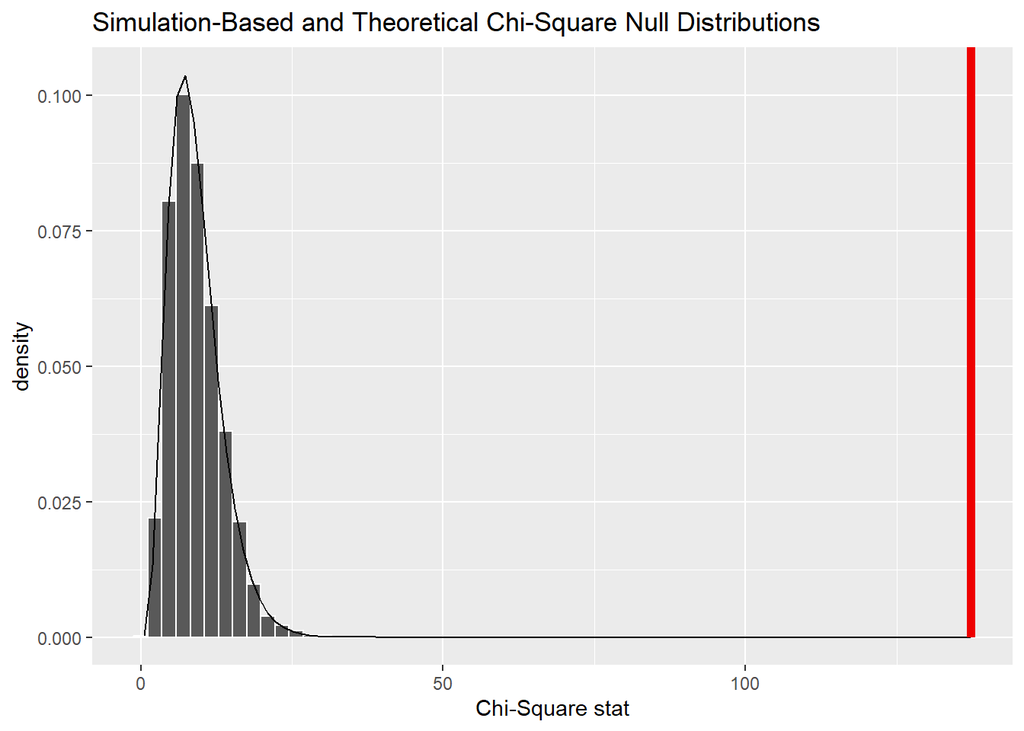

```r
# Convert germination to binary outcome
data <- germination_ex %>%
  mutate(germination_binary = ifelse(germination == "germinated", 1, 0))

# Summarize germination rates per treatment
germination_summary <- data %>%
  group_by(deicer, treatment_level) %>%
  summarise(germination_rate = mean(germination_binary) * 100)

# calculate observed statistic
observed_indep_statistic <- data %>%
  specify(germination ~ treatment) %>%
  calculate(stat = "Chisq")

# generate the null distribution using randomization
null_distribution_simulated <- data %>%
  specify(germination ~ treatment) %>%
  hypothesize(null = "independence") %>%
  generate(reps = 5000, type = "permute") %>%
  calculate(stat = "Chisq")

# visualize both null distributions and the test statistic!
null_distribution_simulated %>%
  visualize(method = "both") +
  shade_p_value(observed_indep_statistic,
                direction = "greater")

# calculate the p value from the observed statistic and null distribution
null_distribution_simulated %>%
  get_p_value(obs_stat = observed_indep_statistic,
              direction = "greater")
```